# Numerical experiments: from simulated data to model comparisons

This notebook demonstrates the complete numerical workflow: define the study, generate and verify frozen data, inspect the data, fit the models, and examine predictions and diagnostics. The same notebook handles both studies. After installing the dependencies listed in the repository README, select a profile above and **Knit**, or run its chunks in order.

## 1. Choose the computation you want

| `profile` | Purpose | Datasets per setting | Chains × iterations (warmup) |
| --- | --- | --- | --- |
| `quick` | Worked example, default | 1 | 1 × 120 (40) |
| `development` | All paper settings with reduced Monte Carlo effort | 3 | 4 × 1,750 (500) |
| `paper` | Configuration used in the paper | 50 | 4 × 20,000 (5,000) |

`study` is `study1`, `study2`, or `both`. The paper has two Study I settings (within-category heterogeneity η = 0 or 1), and three Study II settings (two or four ordinal proxies, plus measurement misspecification). Both paper studies use 100 training and 100 test observations. The quick profile also reduces test sizes and calibration grids; it demonstrates execution and does not estimate the paper’s Monte Carlo results. Development retains the full scientific grid. Paper execution across both studies entails **600 EIV-GP fits** plus ablations and 750 standalone competitor fits, before reuse of saved work.

| study | profile | action | chains | iterations | warmup |
| --- | --- | --- | --- | --- | --- |
| study1 | quick | run | 1 | 120 | 40 |

| cell_id | n | n_test | n_rep | calibration_grid |
| --- | --- | --- | --- | --- |
| eta0_balanced | 100 | 80 | 1 | 0;5 |
| eta1_balanced | 100 | 80 | 1 | 0;5 |

| study | profile | action | chains | iterations | warmup |
| --- | --- | --- | --- | --- | --- |
| study2 | quick | run | 1 | 120 | 40 |

| cell_id | n | n_test | n_rep | calibration_grid |
| --- | --- | --- | --- | --- |
| primary_q2 | 100 | 60 | 1 | 6 |
| primary_q4_calibration | 100 | 60 | 1 | 0;6 |
| logistic_q4 | 100 | 60 | 1 | 6 |

## 2. Freeze and inspect the datasets

A seed identifies each dataset. Calibration subsets are nested and shared across methods. Existing files are verified against their manifests, so rerunning does not silently replace a dataset. Quick, development, and paper artifacts use separate locations. The figures below use the prespecified first replication and show the observed data, rather than fitted GP estimates.

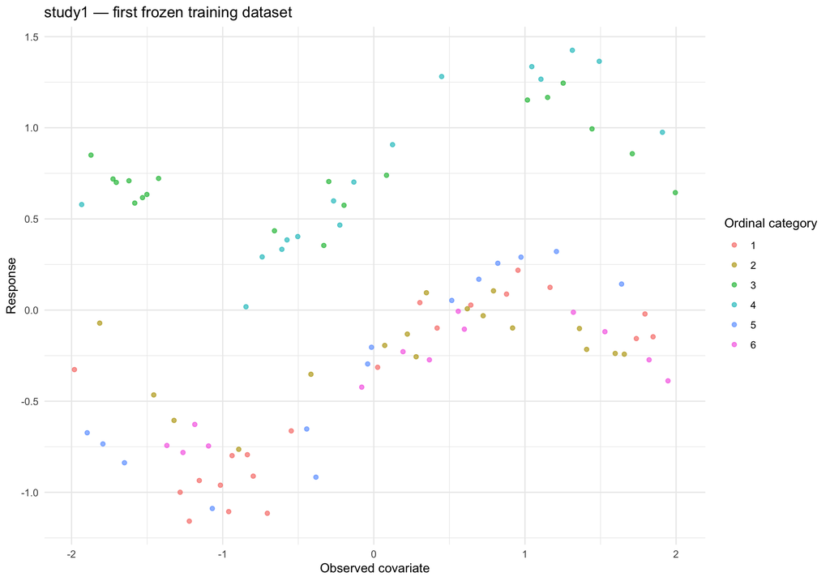

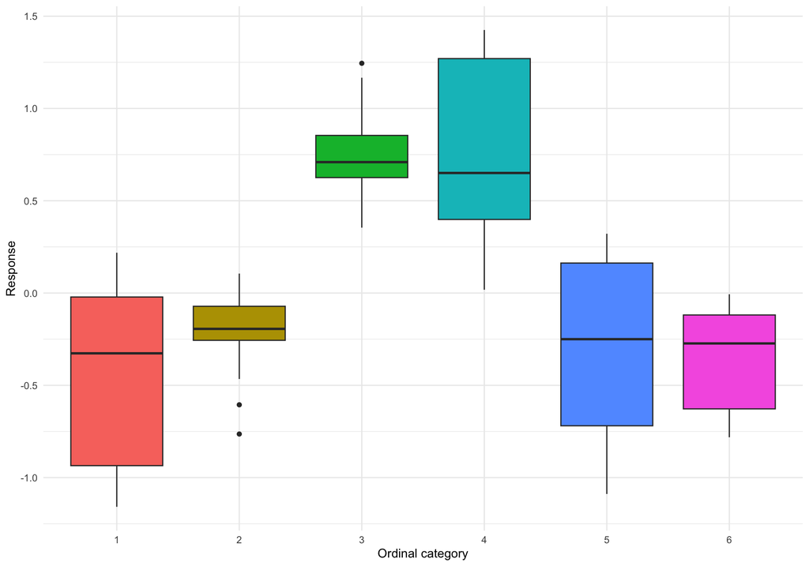

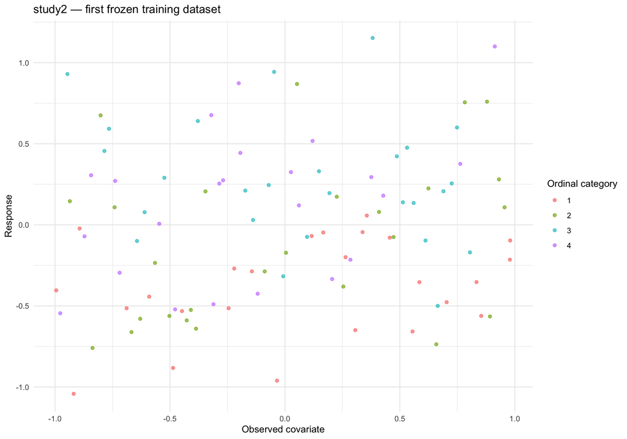

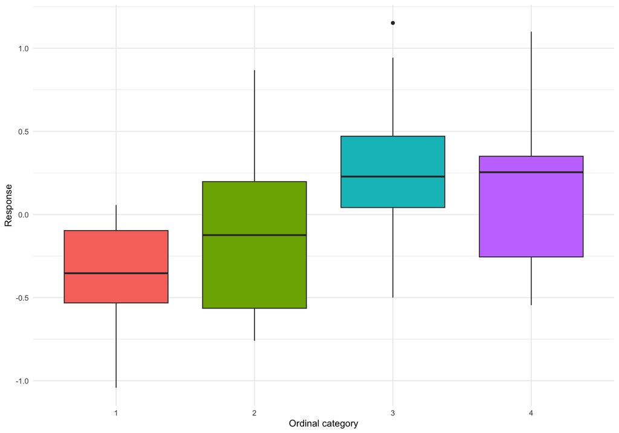

```r
for (config in configs) {
  if (action == "plan") {
    preview <- config; preview$mode <- "dry_run"; preview$stages <- character()
    invisible(notebook_logged(file.path(artifact_root, "logs", paste0(config$study, "-plan.log")), mixedgp_run_simulation(preview)))
  } else if (action != "report") {
    data_config <- config; data_config$stages <- "data"
    frozen <- notebook_logged(file.path(artifact_root, "logs", paste0(config$study, "-data.log")),
      mixedgp_run_simulation(data_config))
    example <- mixedgp_read_cell_replication(config, config$cells[[1L]], 1L)$data$train
    observed <- data.frame(y = example$y,
      x = if (config$study == "study1") example$x else example$X[, 1L],
      category = factor(if (config$study == "study1") example$c else example$C[, 1L]))
    print(ggplot2::ggplot(observed, ggplot2::aes(x, y, color = category)) +
      ggplot2::geom_point(alpha = .65) + ggplot2::theme_minimal() +
      ggplot2::labs(title = paste(config$study, "— first frozen training dataset"),
        x = "Observed covariate", y = "Response", color = "Ordinal category"))
    print(ggplot2::ggplot(observed, ggplot2::aes(category, y, fill = category)) +
      ggplot2::geom_boxplot() + ggplot2::theme_minimal() +
      ggplot2::theme(legend.position = "none") +
      ggplot2::labs(x = "Ordinal category", y = "Response"))
  }
}
```

## 3. Fit the models

EIV-GP learns from responses, observed covariates, ordinal proxies, and the selected exact latent-input measurements. Every method uses the same train/test split. Saved fits allow an interrupted run to resume; compatible completed work is reused. Short chains can flag poor mixing: those warnings remain visible and are not evidence for or against a method.

```r
results <- list()
if (action %in% c("run", "fit")) for (study in studies) {
  fit_config <- configs[[study]]; fit_config$stages <- "fit"
  results[[study]] <- notebook_logged(file.path(artifact_root, "logs", paste0(study, "-fit.log")),
    mixedgp_run_simulation(fit_config))
  gates <- results[[study]]$gates
  assessment <- aggregate(gates$pass, list(setting = gates$cell_id), function(x) paste(sum(x), "/", length(x)))
  names(assessment)[2L] <- "Passed checks"
  print(knitr::kable(assessment))
  if (any(!gates$pass)) cat("\nShort-run MCMC checks are flagged; inspect full diagnostics before interpretation.\n")
}
```

| setting | Passed checks |
| --- | --- |
| eta0_balanced | 5 / 6 |
| eta1_balanced | 7 / 8 |

Short-run MCMC checks are flagged; inspect full diagnostics before interpretation.

| setting | Passed checks |
| --- | --- |
| logistic_q4 | 3 / 4 |
| primary_q2 | 5 / 6 |
| primary_q4_calibration | 7 / 8 |

Short-run MCMC checks are flagged; inspect full diagnostics before interpretation.

## 4. Report and compare

Reporting reads saved fits rather than rerunning MCMC. Prediction errors, interval coverage, proper scores, imputation, and diagnostics answer different questions and should be read together. The full profiles also run the three published competitors independently, reuse their caches, and check dataset identity before combining results. Outputs remain local under `reproduction/`.

study1 — held-out predictive summaries

| cell_id | n_calib | method | RMSE | MAE | Coverage95 |
| --- | --- | --- | --- | --- | --- |
| eta0_balanced | 0 | EIV-GP | 0.176 | 0.138 | 0.963 |
| eta1_balanced | 0 | EIV-GP | 0.562 | 0.460 | 0.912 |
| eta0_balanced | 5 | EIV-GP | 0.177 | 0.143 | 0.950 |
| eta1_balanced | 5 | EIV-GP | 0.534 | 0.430 | 0.925 |

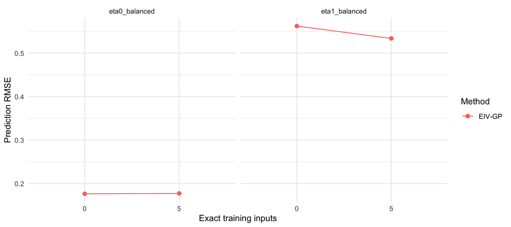

study2 — held-out predictive summaries

| cell_id | n_calib | method | RMSE | MAE | Coverage95 |
| --- | --- | --- | --- | --- | --- |
| primary_q4_calibration | 0 | EIV-GP | 0.389 | 0.290 | 0.800 |
| logistic_q4 | 6 | EIV-GP | 0.365 | 0.271 | 0.900 |
| primary_q2 | 6 | EIV-GP | 0.576 | 0.454 | 0.783 |
| primary_q4_calibration | 6 | EIV-GP | 0.410 | 0.308 | 0.900 |

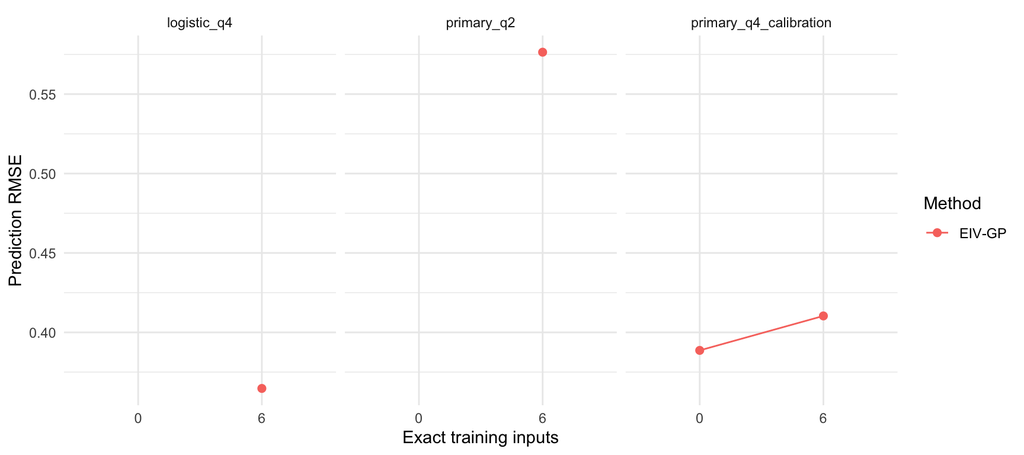

```r
if (action %in% c("run", "report")) for (study in studies) {
  config <- configs[[study]]
  run_dir <- if (!is.null(results[[study]])) results[[study]]$run_dir else mixedgp_run_directory(config)
  reporting <- notebook_logged(file.path(artifact_root, "logs", paste0(study, "-report.log")),
    mixedgp_report_run(run_dir, "report", code_dir = config$code_dir))
  if (any(reporting$status != "success")) stop("Reporting failed; inspect the saved status table.")
  if (profile != "quick") {
    competitor_dir <- file.path(artifact_root, "competitor-reports", study, config$mode)
    competitors <- notebook_logged(file.path(artifact_root, "logs", paste0(study, "-competitors.log")),
      mixedgp_run_competitor_workflow(config, competitor_dir,
        workers = config$parallel$core_budget, action = if (action == "report") "export" else "run"))
    comparison <- mixedgp_combine_saved_runs(run_dir, competitor_dir,
      file.path(run_dir, "reporting", "combined-comparisons"))
    print(knitr::kable(comparison$summary, digits = 3))
    print(knitr::kable(as.data.frame(table(competitors$status$method, competitors$status$status))))
  }
  predictive <- read.csv(file.path(run_dir, "reporting", "combined", "predictive_metrics.csv"))
  if ("evaluation_stratum" %in% names(predictive)) predictive <- predictive[predictive$evaluation_stratum == "overall", ]
  selected <- aggregate(predictive[, c("RMSE", "MAE", "Coverage95")],
    predictive[, c("cell_id", "n_calib", "method")], mean)
  print(knitr::kable(selected, digits = 3,
    caption = paste(study, "— held-out predictive summaries")))
  print(ggplot2::ggplot(selected, ggplot2::aes(factor(n_calib), RMSE, color = method, group = method)) +
    ggplot2::geom_point(size = 2) + ggplot2::geom_line() + ggplot2::facet_wrap(~cell_id) +
    ggplot2::theme_minimal() + ggplot2::labs(x = "Exact training inputs", y = "Prediction RMSE", color = "Method"))
}
```

## 5. Reproduce the paper configuration

| R | eivGP | profile |
| --- | --- | --- |
| 4.6.0 | 0.3.1 | quick |